# Last Time in Text Mining

We talked about Cosine Similarity, K-Means Clustering and Hierarchical Clustering. Tonight, we will talk about MST Clustering, Centroids, Cluster Comparison, Clustering In Sci-Kit Learn, and the Kaggle What’s Cooking Contest.

# Minimum Spanning Trees (MST): Divisive Hierarchical Clustering

A minimum spanning tree (MST) or minimum weight spanning tree is a subset of the edges of a connected, edge-weighted undirected graph that connects all the vertices together, without any cycles and with the minimum possible total edge weight. That is, it is a spanning tree whose sum of edge weights is as small as possible.

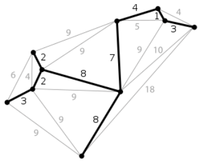

```python
from IPython.display import Image
Image(filename='mst.png')
```

## Building a MST

- Start with a tree that consists of any point.
- In successive steps, look for the closest pair of points (p, q) such that one point (p) is in the current tree but the other (q) is not.
- Add q to the tree and put an edge between p and q.
- Delete K longest paths until you have the required number of clusters.
- E.g. 4 clusters below:{(1),(4),(3,6),(5,2)}.

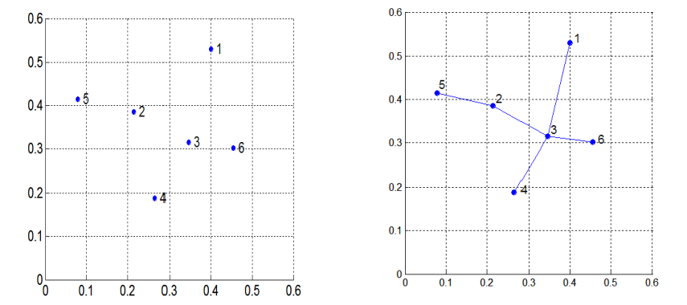

```python
Image(filename='xy_plane_mst.png')
```

## Clustering with MSTs

Recall our documents from last week and their similarities:

|  | **Doc1** | **Doc2** | **Doc3** | **Doc4** |
| --- | --- | --- | --- | --- |
| **Doc1** | 1.00 | 0.57 | 0.00 | 0.00 |
| **Doc2** | 0.57 | 1.00 | 0.50 | 0.00 |
| **Doc3** | 0.00 | 0.50 | 1.00 | 0.39 |
| **Doc4** | 0.00 | 0.00 | 0.39 | 1.00 |

Doc1 and Doc2 go into the tree. Next connect Doc3 to Doc2 in the tree. Next connect Doc4 to Doc3.

If we want 2 clusters disconnect the furthest branch. The branches are:

- Doc1-Doc2 (Similarity =.57 Distance = .43)
- Doc2-Doc3 (Similarity=.50 Distance=.50)
- Doc3-Doc4 (Similarity=.39 Distance=.61)

Disconnect Doc4 and we get 2 clusters {Doc1,Doc2,Doc3},{Doc4}. If we wanted 3 clusters we get {Doc1, Doc2}, {Doc3}, {Doc4}.

## MST in Python

Remember those movies we looked at last week? Let's go back to those.

```python
#import packages
import pandas as pd

# define dataframe
data = pd.read_csv('movies.csv')

# display first 3 rows of dataframe
data.head(3)
```

|  | Rank | Title | Professor | User2 | User3 | Thomas | User5 | User6 | Mason | User8 |
| --- | --- | --- | --- | --- | --- | --- | --- | --- | --- | --- |
| 0 | 1 | The Wizard of Oz (1939) | 1 | 1 | 1 | 2 | 2 | 2 | 1 | 1 |
| 1 | 2 | The Third Man (1949) | 1 | 0 | 0 | 2 | 0 | 0 | 0 | 0 |
| 2 | 3 | Citizen Kane (1941) | 1 | 2 | 0 | 1 | 2 | 1 | 0 | 0 |

```python
# display last 3 rows of dataframe
data.tail(3)
```

|  | Rank | Title | Professor | User2 | User3 | Thomas | User5 | User6 | Mason | User8 |
| --- | --- | --- | --- | --- | --- | --- | --- | --- | --- | --- |
| 97 | 98 | Gloria (2014) | 0 | 0 | 0 | 0 | 0 | 0 | 0 | 0 |
| 98 | 99 | Aguirre, der Zorn Gottes (Aguirre, the Wrath o... | 0 | 0 | 0 | 0 | 0 | 0 | 0 | 0 |
| 99 | 100 | Forbidden Planet (1956) | 1 | 0 | 0 | 0 | 0 | 0 | 0 | 0 |

```python
# drop rank and title and transpose df
data_transpose = data.drop(['Rank', 'Title'], axis=1).T

# display data_traspose
data_transpose
```

|  | 0 | 1 | 2 | 3 | 4 | 5 | 6 | 7 | 8 | 9 | ... | 90 | 91 | 92 | 93 | 94 | 95 | 96 | 97 | 98 | 99 |
| --- | --- | --- | --- | --- | --- | --- | --- | --- | --- | --- | --- | --- | --- | --- | --- | --- | --- | --- | --- | --- | --- |
| Professor | 1 | 1 | 1 | 1 | 0 | 0 | 0 | 2 | 0 | 0 | ... | 0 | 2 | 0 | 0 | 0 | 0 | 0 | 0 | 0 | 1 |
| User2 | 1 | 0 | 2 | 0 | 0 | 0 | 0 | 2 | 2 | 0 | ... | 0 | 0 | 2 | 0 | 0 | 0 | 0 | 0 | 0 | 0 |
| User3 | 1 | 0 | 0 | 0 | 0 | 0 | 0 | 2 | 0 | 0 | ... | 0 | 0 | 0 | 0 | 0 | 0 | 0 | 0 | 0 | 0 |
| Thomas | 2 | 2 | 1 | 2 | 0 | -1 | 0 | 2 | -2 | 0 | ... | -1 | 2 | 0 | 1 | 0 | 0 | 2 | 0 | 0 | 0 |
| User5 | 2 | 0 | 2 | 0 | 2 | 0 | 0 | 2 | 0 | 0 | ... | 0 | 0 | 1 | 0 | 0 | 0 | 0 | 0 | 0 | 0 |
| User6 | 2 | 0 | 1 | 0 | 0 | 0 | 0 | 2 | 2 | 0 | ... | 0 | 0 | 1 | 0 | 0 | 0 | 0 | 0 | 0 | 0 |
| Mason | 1 | 0 | 0 | 0 | 0 | 1 | 0 | 1 | 2 | 0 | ... | 0 | 0 | -1 | 0 | 1 | 0 | 0 | 0 | 0 | 0 |
| User8 | 1 | 0 | 0 | 0 | 0 | 0 | 0 | 1 | 0 | -2 | ... | 0 | 0 | 0 | 0 | 0 | 0 | 0 | 0 | 0 | 0 |

8 rows × 100 columns

```python
# import package
from scipy.spatial.distance import cosine

# define a list of names
users = data_transpose.index

# define a similarity matrix, which is actually a pandas dataframe in this case
similarity_matrix = pd.DataFrame(columns=users)

# define a distance matrix, which is actually a pandas dataframe in this case
distance_matrix = pd.DataFrame(columns=users)

# define i
i = 0

# loop over users
for user in users:

    # define two empty lists
    cosine_sims = []
    dist_vals = []

    # loop over users again (we aren't worried about O(n^2) here, since
    # we only have 11 users)
    for user2 in users:

        # calculate the cosine similarity (note from scipy.spatial.distance
        # import cosine calculates distance when calling cosine.
        # Simply take 1 - value to get cosine similarity. Additionally, this
        # time we will be going row wise instead of column wise. See if you
        # can spot the difference between this weeks code and last weeks
        cos_val = round(1 - cosine(data_transpose.loc[user],
                                   data_transpose.loc[user2]),3)

        # caluclate distance
        dis_val = round(cosine(data_transpose.loc[user],
                               data_transpose.loc[user2]),3)

        # append values to empty lists
        cosine_sims.append(cos_val)
        dist_vals.append(dis_val)

    # append cosine_sims and dist_vals to the appropriate matricies
    similarity_matrix.loc[i] = cosine_sims
    distance_matrix.loc[i] = dist_vals

    # increment i
    i = i+1

# set similarity_matrix.index to users, same for distance_matrix
similarity_matrix.index = users
distance_matrix.index = users
```

```python
distance_matrix
```

|  | Professor | User2 | User3 | Thomas | User5 | User6 | Mason | User8 |
| --- | --- | --- | --- | --- | --- | --- | --- | --- |
| Professor | 0.000 | 0.571 | 0.605 | 0.465 | 0.512 | 0.606 | 0.510 | 0.464 |
| User2 | 0.571 | 0.000 | 0.517 | 0.728 | 0.526 | 0.360 | 0.585 | 0.676 |
| User3 | 0.605 | 0.517 | 0.000 | 0.763 | 0.401 | 0.395 | 0.403 | 0.441 |
| Thomas | 0.465 | 0.728 | 0.763 | 0.000 | 0.659 | 0.829 | 0.839 | 0.694 |
| User5 | 0.512 | 0.526 | 0.401 | 0.659 | 0.000 | 0.377 | 0.378 | 0.527 |
| User6 | 0.606 | 0.360 | 0.395 | 0.829 | 0.377 | 0.000 | 0.420 | 0.643 |
| Mason | 0.510 | 0.585 | 0.403 | 0.839 | 0.378 | 0.420 | 0.000 | 0.498 |
| User8 | 0.464 | 0.676 | 0.441 | 0.694 | 0.527 | 0.643 | 0.498 | 0.000 |

Now we can find the minimum distance (which will be an edge) between each vector (each vector will be a vertex in our graph)!

```python
# define an empty dictionary
edge_distances = {}

# loop over users
for user in distance_matrix.columns:

    # get the min value in each column greater than 0 (we would just get the
    # distance from a vector to itself!)
    min_val = distance_matrix[user][distance_matrix[user]>0].min()

    # get the vector name (column)
    vertex1 = user
    # get the name of the vector tht is closest (its stored in the index)
    vertex2 = distance_matrix.index[distance_matrix[user]==min_val].to_list()[0]
    # alphabetize the two vectors
    vertecies = sorted([vertex1,vertex2])
    # reassign the vertecies in alphabetical order so that the dictionary doesnt
    # have extra entries
    v1 = vertecies[0]
    v2 = vertecies[1]
    # fill dictionary
    edge_distances[v1+'-'+v2]=min_val
```

```python
edge_distances
```

```
{'Professor-User8': 0.464,
 'User2-User6': 0.36,
 'User3-User6': 0.395,
 'Professor-Thomas': 0.465,
 'User5-User6': 0.377,
 'Mason-User5': 0.378,
 'User3-User8': 0.441}
```

```python
# sort in ascending order
{k: v for k, v in sorted(edge_distances.items(),
                         key=lambda item: item[1],
                         reverse=False)}
```

```
{'User2-User6': 0.36,
 'User5-User6': 0.377,
 'Mason-User5': 0.378,
 'User3-User6': 0.395,
 'User3-User8': 0.441,
 'Professor-User8': 0.464,
 'Professor-Thomas': 0.465}
```

Here's what the users look like an a MST:

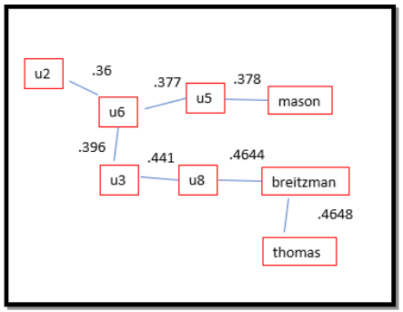

```python
Image(filename='movies_mst.png')
```

Not a great example because we get a bunch of size one clusters each time we delete a path. Here's an example using cities in the USA.

```python
# load in cities.csv to a dataframe
cities = pd.read_csv('cities.csv')

# display dataframe
cities
```

|  | City | Seattle | Phoenix | Minneapolis | Madison | Chicago | Philadelphia | New York | Boston | Orlando | Washington DC |
| --- | --- | --- | --- | --- | --- | --- | --- | --- | --- | --- | --- |
| 0 | Seattle | 0 | 1110 | 1390 | 1620 | 1710 | 2370 | 2410 | 2490 | 2450 | 2300 |
| 1 | Phoenix | 1110 | 0 | 1270 | 1390 | 1440 | 2070 | 2150 | 2290 | 1760 | 1950 |
| 2 | Minneapolis | 1390 | 1270 | 0 | 227 | 333 | 977 | 1020 | 1120 | 1210 | 682 |
| 3 | Madison | 1620 | 1390 | 227 | 0 | 108 | 762 | 817 | 928 | 1010 | 682 |
| 4 | Chicago | 1710 | 1440 | 333 | 108 | 0 | 676 | 737 | 863 | 904 | 587 |
| 5 | Philadelphia | 2370 | 2070 | 977 | 762 | 676 | 0 | 93 | 278 | 808 | 135 |
| 6 | New York | 2410 | 2150 | 1020 | 817 | 737 | 93 | 0 | 186 | 894 | 227 |
| 7 | Boston | 2490 | 2290 | 1120 | 928 | 863 | 278 | 186 | 0 | 1080 | 411 |
| 8 | Orlando | 2450 | 1760 | 1210 | 1010 | 904 | 808 | 894 | 1080 | 0 | 696 |
| 9 | Washington DC | 2300 | 1950 | 682 | 682 | 587 | 135 | 227 | 411 | 696 | 0 |

```python
# display dataframe shape
cities.shape
```

```
(10, 11)
```

```python
# create a duplicate of cities, called cities2, drop the city column and transpose the df
cities2 = cities.drop(['City'], axis=1).T

# display cities2
cities2
```

|  | 0 | 1 | 2 | 3 | 4 | 5 | 6 | 7 | 8 | 9 |
| --- | --- | --- | --- | --- | --- | --- | --- | --- | --- | --- |
| Seattle | 0 | 1110 | 1390 | 1620 | 1710 | 2370 | 2410 | 2490 | 2450 | 2300 |
| Phoenix | 1110 | 0 | 1270 | 1390 | 1440 | 2070 | 2150 | 2290 | 1760 | 1950 |
| Minneapolis | 1390 | 1270 | 0 | 227 | 333 | 977 | 1020 | 1120 | 1210 | 682 |
| Madison | 1620 | 1390 | 227 | 0 | 108 | 762 | 817 | 928 | 1010 | 682 |
| Chicago | 1710 | 1440 | 333 | 108 | 0 | 676 | 737 | 863 | 904 | 587 |
| Philadelphia | 2370 | 2070 | 977 | 762 | 676 | 0 | 93 | 278 | 808 | 135 |
| New York | 2410 | 2150 | 1020 | 817 | 737 | 93 | 0 | 186 | 894 | 227 |
| Boston | 2490 | 2290 | 1120 | 928 | 863 | 278 | 186 | 0 | 1080 | 411 |
| Orlando | 2450 | 1760 | 1210 | 1010 | 904 | 808 | 894 | 1080 | 0 | 696 |
| Washington DC | 2300 | 1950 | 682 | 682 | 587 | 135 | 227 | 411 | 696 | 0 |

```python
# display dataframe shape
cities2.shape
```

```
(10, 10)
```

We can of course work with the data in a dataframe, however, if you ever need the data in an array, this is an option:

```python
city_names = cities['City']

city_names
```

```
0          Seattle
1          Phoenix
2      Minneapolis
3          Madison
4          Chicago
5     Philadelphia
6         New York
7           Boston
8          Orlando
9    Washington DC
Name: City, dtype: object
```

```python
distances = cities2.values

distances
```

```
array([[   0, 1110, 1390, 1620, 1710, 2370, 2410, 2490, 2450, 2300],
       [1110,    0, 1270, 1390, 1440, 2070, 2150, 2290, 1760, 1950],
       [1390, 1270,    0,  227,  333,  977, 1020, 1120, 1210,  682],
       [1620, 1390,  227,    0,  108,  762,  817,  928, 1010,  682],
       [1710, 1440,  333,  108,    0,  676,  737,  863,  904,  587],
       [2370, 2070,  977,  762,  676,    0,   93,  278,  808,  135],
       [2410, 2150, 1020,  817,  737,   93,    0,  186,  894,  227],
       [2490, 2290, 1120,  928,  863,  278,  186,    0, 1080,  411],
       [2450, 1760, 1210, 1010,  904,  808,  894, 1080,    0,  696],
       [2300, 1950,  682,  682,  587,  135,  227,  411,  696,    0]],
      dtype=int64)
```

Here's an expanded version of what was done above with the movies. The distances from each vertex to every other is necessary to draw a graph, but I did not want to bog you down with too much in the beginning:

```python
# look at lower triangle and store in a dict

city_distances = {}

for i in range(cities2.shape[0]):

    for j in range(i+1, cities2.shape[1]):

        city_distances[city_names[i]+'-'+city_names[j]]=distances[i,j]

city_distances
```

```
{'Seattle-Phoenix': 1110,
 'Seattle-Minneapolis': 1390,
 'Seattle-Madison': 1620,
 'Seattle-Chicago': 1710,
 'Seattle-Philadelphia': 2370,
 'Seattle-New York': 2410,
 'Seattle-Boston': 2490,
 'Seattle-Orlando': 2450,
 'Seattle-Washington DC': 2300,
 'Phoenix-Minneapolis': 1270,
 'Phoenix-Madison': 1390,
 'Phoenix-Chicago': 1440,
 'Phoenix-Philadelphia': 2070,
 'Phoenix-New York': 2150,
 'Phoenix-Boston': 2290,
 'Phoenix-Orlando': 1760,
 'Phoenix-Washington DC': 1950,
 'Minneapolis-Madison': 227,
 'Minneapolis-Chicago': 333,
 'Minneapolis-Philadelphia': 977,
 'Minneapolis-New York': 1020,
 'Minneapolis-Boston': 1120,
 'Minneapolis-Orlando': 1210,
 'Minneapolis-Washington DC': 682,
 'Madison-Chicago': 108,
 'Madison-Philadelphia': 762,
 'Madison-New York': 817,
 'Madison-Boston': 928,
 'Madison-Orlando': 1010,
 'Madison-Washington DC': 682,
 'Chicago-Philadelphia': 676,
 'Chicago-New York': 737,
 'Chicago-Boston': 863,
 'Chicago-Orlando': 904,
 'Chicago-Washington DC': 587,
 'Philadelphia-New York': 93,
 'Philadelphia-Boston': 278,
 'Philadelphia-Orlando': 808,
 'Philadelphia-Washington DC': 135,
 'New York-Boston': 186,
 'New York-Orlando': 894,
 'New York-Washington DC': 227,
 'Boston-Orlando': 1080,
 'Boston-Washington DC': 411,
 'Orlando-Washington DC': 696}
```

```python
# sort in ascending order
{k: v for k, v in sorted(city_distances.items(),
                         key=lambda item: item[1])}
```

```
{'Philadelphia-New York': 93,
 'Madison-Chicago': 108,
 'Philadelphia-Washington DC': 135,
 'New York-Boston': 186,
 'Minneapolis-Madison': 227,
 'New York-Washington DC': 227,
 'Philadelphia-Boston': 278,
 'Minneapolis-Chicago': 333,
 'Boston-Washington DC': 411,
 'Chicago-Washington DC': 587,
 'Chicago-Philadelphia': 676,
 'Minneapolis-Washington DC': 682,
 'Madison-Washington DC': 682,
 'Orlando-Washington DC': 696,
 'Chicago-New York': 737,
 'Madison-Philadelphia': 762,
 'Philadelphia-Orlando': 808,
 'Madison-New York': 817,
 'Chicago-Boston': 863,
 'New York-Orlando': 894,
 'Chicago-Orlando': 904,
 'Madison-Boston': 928,
 'Minneapolis-Philadelphia': 977,
 'Madison-Orlando': 1010,
 'Minneapolis-New York': 1020,
 'Boston-Orlando': 1080,
 'Seattle-Phoenix': 1110,
 'Minneapolis-Boston': 1120,
 'Minneapolis-Orlando': 1210,
 'Phoenix-Minneapolis': 1270,
 'Seattle-Minneapolis': 1390,
 'Phoenix-Madison': 1390,
 'Phoenix-Chicago': 1440,
 'Seattle-Madison': 1620,
 'Seattle-Chicago': 1710,
 'Phoenix-Orlando': 1760,
 'Phoenix-Washington DC': 1950,
 'Phoenix-Philadelphia': 2070,
 'Phoenix-New York': 2150,
 'Phoenix-Boston': 2290,
 'Seattle-Washington DC': 2300,
 'Seattle-Philadelphia': 2370,
 'Seattle-New York': 2410,
 'Seattle-Orlando': 2450,
 'Seattle-Boston': 2490}
```

And here's that graphically:

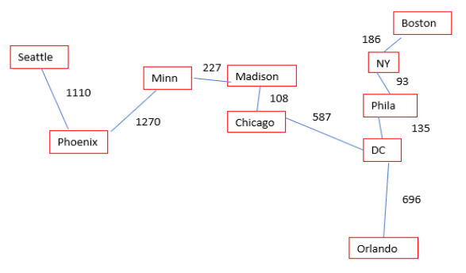

```python
Image(filename='cities_mst.png')
```

I should have put in Portland and Atlanta to make it more interesting. If we delete 4 longest distances (1270, 1110, 696, 587) then I get Northeast Cluster, Midwest Cluster and then Seattle, Phoenix, Florida are singletons. But, overall, interesting none the less!

That's it for MSTs!

# Centroids

What’s a Centroid? Roughly speaking a centroid is a point (not necessarily in our data set) that would be in the center of our cluster. It is the point such that the sum of the distances between it and all other points in the cluster is minimized. We only care about centroids when we use k-means Clustering; we don’t actually need centroids for hierarchical clustering!

Now the question is what the heck is the centroid of a cluster of documents? Each document is a vector. A cluster of documents is a bunch of vectors whose angle between them are small.

That seems like something that would be painful to compute (**Spolier Alert**, it's actually pretty simple).

## Revisiting our Document Vectors

Remember these guys from last week?

| **DocID** | **Document Content** | **TF-IDF Vector** |
| --- | --- | --- |
| Doc1 | time time me | <0,0,0,3,4> |
| Doc2 | time fly | <0,2,0,0,2> |
| Doc3 | fly away | <2,2,0,0,0> |
| Doc 4 | go away | <2,0,3,0,0> |

What is the centroid if Doc1, Doc2, and Doc3 are clustered together?

Well it’s a vector C=<a,b,c,d,e> such that the sum of the distances between C and the other documents is minimized. We could probably solve for a,b,c,d,e although it seems like a lot of work.

Spoiler alert. If we just add the vectors together we get the centroid. Yes C=<2,4,0,3,6> Isn't math wild?

## Clusteroids

Recall that a centroid need not be a point in the cluster. It’s thought of as the center point, or the point that is most equidistant to all the points in the cluster!

A clustroid, on the other hand, is an actual point in the cluster that is closest to the actual theoretical centroid. (If we have a crowded cluster, the clustroid will be very close to the centroid).

We use clustroids when the centroid would be hard to compute. For example, if we have an exotic distance function, then the clustroid is the point in the cluster that is closest to all the other points using that distance function. As a practical matter, we compute it by computing the sum of squares of distances between all points and all other points in the cluster. Here's a vidulaization:

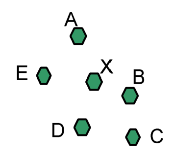

```python
Image(filename='euclidean_clustroids.png')
```

In the case of Euclidean distance, we see that X would be fairly close to the actual centroid. It’s clear that the sum of the square of distances between X and everything else is much smaller than the sum of the squares of distances from say A and everything else. The clustroid can be computed using whatever distance function we have in an analogous way!

If you're doing this in Python or R, there are a ton of libraries to help you out (Sci-Kit Learn or SciPy in Python, not too sure about R). Here are a few things to be aware of:

- If it takes a distance matrix that it doesn’t just assume it’s Euclidean distance!
- If it says spherical k-means, then it’s cosine, but otherwise many k-means functions will default to Euclidean.
- If you are using a distance measure on mixed data types you may have to use your own distance function and calculate your own clustroids to get proper behavior.

If you want to read up on this, check out [this link](https://stackoverflow.com/questions/19226925/spherical-k-means-implementation-in-python) for some tips and tricks in Python!

## Centroids in Python

They say a picture is worth 1000 words, so how many is a guided exercise worth? Let's do some centroid calculation in python.

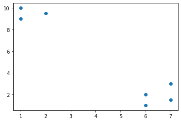

```python
# import libraries
import matplotlib.pyplot as plt

# define lists x,y
x = [1,1,2,6,6,7,7]
y = [9,10,9.5,1,2,1.5,3]

# call matplotlib.pyplot to draw scatterplot
plt.scatter(x,y)

# show plot
plt.show()

# close plot
plt.close()
```

Let's put these values in a dataframe...

```python
# import library
import pandas as pd

# define dataframe
m = pd.DataFrame(data=[x,y], columns=["a","b","c","q","r","s","t"],
                 index=['x','y'])

m
```

|  | a | b | c | q | r | s | t |
| --- | --- | --- | --- | --- | --- | --- | --- |
| x | 1 | 1 | 2.0 | 6 | 6 | 7.0 | 7 |
| y | 9 | 10 | 9.5 | 1 | 2 | 1.5 | 3 |

I think we should choose a and t as out initial centroids.

We've seen something similar before, but in case your as forgetful as am, we are going touse this to calculate similarity (or distances). Remember, similarity matricies have 1s on the diagonal and distance matricies have 0s.

```python
from scipy.spatial.distance import cosine

values = m.columns
similarity_matrix = pd.DataFrame(columns=values)

i = 0
for val in values:
    to_append = []
    for val2 in values:
        cos_vec = 1 - cosine(m[val], m[val2])
        to_append.append(cos_vec)
    similarity_matrix.loc[i] = to_append
    i = i+1

similarity_matrix.index = similarity_matrix.columns
similarity_matrix
```

|  | a | b | c | q | r | s | t |
| --- | --- | --- | --- | --- | --- | --- | --- |
| a | 1.000000 | 0.999940 | 0.995315 | 0.272322 | 0.419058 | 0.316228 | 0.493013 |
| b | 0.999940 | 1.000000 | 0.994192 | 0.261733 | 0.409056 | 0.305784 | 0.483423 |
| c | 0.995315 | 0.994192 | 1.000000 | 0.364080 | 0.504883 | 0.406472 | 0.574823 |
| q | 0.272322 | 0.261733 | 0.364080 | 1.000000 | 0.987763 | 0.998945 | 0.971399 |
| r | 0.419058 | 0.409056 | 0.504883 | 0.987763 | 1.000000 | 0.993884 | 0.996546 |
| s | 0.316228 | 0.305784 | 0.406472 | 0.998945 | 0.993884 | 1.000000 | 0.981280 |
| t | 0.493013 | 0.483423 | 0.574823 | 0.971399 | 0.996546 | 0.981280 | 1.000000 |

With a and t as out initial centroids, we can tell that a, b, and c cluster and q, r, s, and t cluster. Let's get those centroids:

```python
# What's the centroid of a,b,c?

c1_x = 1+1+2
c1_y = 9+10+9.5

# what's the centroid of q,r,s,t
c2_x = 6+6+7+7
c2_y = 1+2+1.5+3

# insert in m
m['c1'] = [c1_x, c1_y]
m['c2'] = [c2_x, c2_y]

m
```

|  | a | b | c | q | r | s | t | c1 | c2 |
| --- | --- | --- | --- | --- | --- | --- | --- | --- | --- |
| x | 1 | 1 | 2.0 | 6 | 6 | 7.0 | 7 | 4.0 | 26.0 |
| y | 9 | 10 | 9.5 | 1 | 2 | 1.5 | 3 | 28.5 | 7.5 |

Those values seem a little suspect, so let's double check the similarity:

```python
values = m.columns
similarity_matrix = pd.DataFrame(columns=values)

i = 0
for val in values:
    to_append = []
    for val2 in values:
        cos_vec = 1 - cosine(m[val], m[val2])
        to_append.append(cos_vec)
    similarity_matrix.loc[i] = to_append
    i = i+1

similarity_matrix.index = similarity_matrix.columns
similarity_matrix
```

|  | a | b | c | q | r | s | t | c1 | c2 |
| --- | --- | --- | --- | --- | --- | --- | --- | --- | --- |
| a | 1.000000 | 0.999940 | 0.995315 | 0.272322 | 0.419058 | 0.316228 | 0.493013 | 0.999586 | 0.381571 |
| b | 0.999940 | 1.000000 | 0.994192 | 0.261733 | 0.409056 | 0.305784 | 0.483423 | 0.999209 | 0.371391 |
| c | 0.995315 | 0.994192 | 1.000000 | 0.364080 | 0.504883 | 0.406472 | 0.574823 | 0.997685 | 0.469155 |
| q | 0.272322 | 0.261733 | 0.364080 | 1.000000 | 0.987763 | 0.998945 | 0.971399 | 0.299901 | 0.993315 |
| r | 0.419058 | 0.409056 | 0.504883 | 0.987763 | 1.000000 | 0.993884 | 0.996546 | 0.445015 | 0.999163 |
| s | 0.316228 | 0.305784 | 0.406472 | 0.998945 | 0.993884 | 1.000000 | 0.981280 | 0.343399 | 0.997569 |
| t | 0.493013 | 0.483423 | 0.574823 | 0.971399 | 0.996546 | 0.981280 | 1.000000 | 0.517847 | 0.992315 |
| c1 | 0.999586 | 0.999209 | 0.997685 | 0.299901 | 0.445015 | 0.343399 | 0.517847 | 1.000000 | 0.408014 |
| c2 | 0.381571 | 0.371391 | 0.469155 | 0.993315 | 0.999163 | 0.997569 | 0.992315 | 0.408014 | 1.000000 |

Turns out that it works! Here's the data graphically (with the centroids in red):

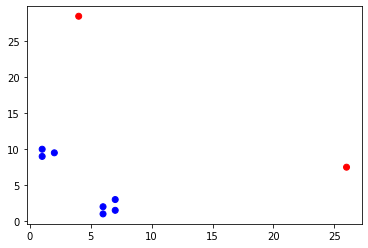

```python
plt.scatter(m.loc['x'],m.loc['y'], color=[
    "blue","blue","blue","blue","blue","blue","blue","red","red"])

plt.show()

plt.close()
```

Notice the centroid vectors do indeed have angles that fall in between their respective clusters. But they are somehow unsatisfying to look at. This doesn't matter in higher dimensions because we can't visualize them anyway. However, if it bothers you we can always turn all of our vectors into unit vectors without affecting the angles.

First lets calculate the norm of each vector and make it its own row in m:

```python
from math import sqrt

norms = []
for value in m.columns:
    norm = sqrt(m[value].loc['x']*m[value].loc['x']+
         m[value].loc['y']*m[value].loc['y'])
    norms.append(norm)

m.loc['norms'] = norms

m.loc['x_unit'] = m.loc['x']/m.loc['norms']
m.loc['y_unit'] = m.loc['y']/m.loc['norms']

m
```

|  | a | b | c | q | r | s | t | c1 | c2 |
| --- | --- | --- | --- | --- | --- | --- | --- | --- | --- |
| x | 1.000000 | 1.000000 | 2.000000 | 6.000000 | 6.000000 | 7.000000 | 7.000000 | 4.000000 | 26.000000 |
| y | 9.000000 | 10.000000 | 9.500000 | 1.000000 | 2.000000 | 1.500000 | 3.000000 | 28.500000 | 7.500000 |
| norms | 9.055385 | 10.049876 | 9.708244 | 6.082763 | 6.324555 | 7.158911 | 7.615773 | 28.779333 | 27.060118 |
| x_unit | 0.110432 | 0.099504 | 0.206010 | 0.986394 | 0.948683 | 0.977802 | 0.919145 | 0.138989 | 0.960824 |
| y_unit | 0.993884 | 0.995037 | 0.978550 | 0.164399 | 0.316228 | 0.209529 | 0.393919 | 0.990294 | 0.277161 |

And the normalized data graphically:

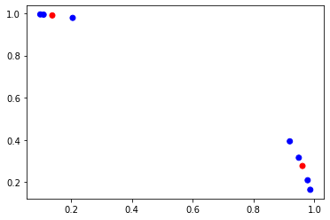

```python
plt.scatter(m.loc['x_unit'],m.loc['y_unit'], color=[
    "blue","blue","blue","blue","blue","blue","blue","red","red"])
plt.show()

plt.close()
```

Let's calculate the similarities for the normalized vectors:

```python
values = m.columns
similarity_matrix_m3 = pd.DataFrame(columns=values)

m3 = m.copy()

m3 = m3.drop(index=['norms', 'x', 'y'])

i = 0
for val in values:
    to_append = []
    for val2 in values:
        cos_vec = 1 - cosine(m3[val], m3[val2])
        to_append.append(cos_vec)
    similarity_matrix_m3.loc[i] = to_append
    i = i+1

similarity_matrix_m3
```

|  | a | b | c | q | r | s | t | c1 | c2 |
| --- | --- | --- | --- | --- | --- | --- | --- | --- | --- |
| 0 | 1.000000 | 0.999940 | 0.995315 | 0.272322 | 0.419058 | 0.316228 | 0.493013 | 0.999586 | 0.381571 |
| 1 | 0.999940 | 1.000000 | 0.994192 | 0.261733 | 0.409056 | 0.305784 | 0.483423 | 0.999209 | 0.371391 |
| 2 | 0.995315 | 0.994192 | 1.000000 | 0.364080 | 0.504883 | 0.406472 | 0.574823 | 0.997685 | 0.469155 |
| 3 | 0.272322 | 0.261733 | 0.364080 | 1.000000 | 0.987763 | 0.998945 | 0.971399 | 0.299901 | 0.993315 |
| 4 | 0.419058 | 0.409056 | 0.504883 | 0.987763 | 1.000000 | 0.993884 | 0.996546 | 0.445015 | 0.999163 |
| 5 | 0.316228 | 0.305784 | 0.406472 | 0.998945 | 0.993884 | 1.000000 | 0.981280 | 0.343399 | 0.997569 |
| 6 | 0.493013 | 0.483423 | 0.574823 | 0.971399 | 0.996546 | 0.981280 | 1.000000 | 0.517847 | 0.992315 |
| 7 | 0.999586 | 0.999209 | 0.997685 | 0.299901 | 0.445015 | 0.343399 | 0.517847 | 1.000000 | 0.408014 |
| 8 | 0.381571 | 0.371391 | 0.469155 | 0.993315 | 0.999163 | 0.997569 | 0.992315 | 0.408014 | 1.000000 |

Are th similarities the same using normalized and un-normalized vectors? Probably, but let's see. Here's a quick was to check. First i'll recaleculate the original similarity matrix...

```python
values = m.columns
similarity_matrix = pd.DataFrame(columns=values)

i = 0
for val in values:
    to_append = []
    for val2 in values:
        cos_vec = 1 - cosine(m[val].loc[['x','y']], m[val2].loc[['x','y']])
        to_append.append(cos_vec)
    similarity_matrix.loc[i] = to_append
    i = i+1
similarity_matrix
```

|  | a | b | c | q | r | s | t | c1 | c2 |
| --- | --- | --- | --- | --- | --- | --- | --- | --- | --- |
| 0 | 1.000000 | 0.999940 | 0.995315 | 0.272322 | 0.419058 | 0.316228 | 0.493013 | 0.999586 | 0.381571 |
| 1 | 0.999940 | 1.000000 | 0.994192 | 0.261733 | 0.409056 | 0.305784 | 0.483423 | 0.999209 | 0.371391 |
| 2 | 0.995315 | 0.994192 | 1.000000 | 0.364080 | 0.504883 | 0.406472 | 0.574823 | 0.997685 | 0.469155 |
| 3 | 0.272322 | 0.261733 | 0.364080 | 1.000000 | 0.987763 | 0.998945 | 0.971399 | 0.299901 | 0.993315 |
| 4 | 0.419058 | 0.409056 | 0.504883 | 0.987763 | 1.000000 | 0.993884 | 0.996546 | 0.445015 | 0.999163 |
| 5 | 0.316228 | 0.305784 | 0.406472 | 0.998945 | 0.993884 | 1.000000 | 0.981280 | 0.343399 | 0.997569 |
| 6 | 0.493013 | 0.483423 | 0.574823 | 0.971399 | 0.996546 | 0.981280 | 1.000000 | 0.517847 | 0.992315 |
| 7 | 0.999586 | 0.999209 | 0.997685 | 0.299901 | 0.445015 | 0.343399 | 0.517847 | 1.000000 | 0.408014 |
| 8 | 0.381571 | 0.371391 | 0.469155 | 0.993315 | 0.999163 | 0.997569 | 0.992315 | 0.408014 | 1.000000 |

Now I can subtract them:

```python
(similarity_matrix - similarity_matrix_m3).round()
```

|  | a | b | c | q | r | s | t | c1 | c2 |
| --- | --- | --- | --- | --- | --- | --- | --- | --- | --- |
| 0 | 0.0 | 0.0 | -0.0 | -0.0 | -0.0 | 0.0 | 0.0 | -0.0 | 0.0 |
| 1 | 0.0 | 0.0 | -0.0 | 0.0 | -0.0 | -0.0 | 0.0 | -0.0 | 0.0 |
| 2 | -0.0 | -0.0 | 0.0 | -0.0 | -0.0 | 0.0 | 0.0 | -0.0 | -0.0 |
| 3 | -0.0 | 0.0 | -0.0 | 0.0 | 0.0 | -0.0 | -0.0 | -0.0 | 0.0 |
| 4 | -0.0 | -0.0 | -0.0 | 0.0 | 0.0 | -0.0 | -0.0 | -0.0 | -0.0 |
| 5 | 0.0 | -0.0 | 0.0 | -0.0 | -0.0 | 0.0 | -0.0 | 0.0 | -0.0 |
| 6 | 0.0 | 0.0 | 0.0 | -0.0 | -0.0 | -0.0 | 0.0 | -0.0 | 0.0 |
| 7 | -0.0 | -0.0 | -0.0 | -0.0 | -0.0 | 0.0 | -0.0 | 0.0 | 0.0 |
| 8 | 0.0 | 0.0 | -0.0 | 0.0 | -0.0 | -0.0 | 0.0 | 0.0 | 0.0 |

Nice

# Bottom Line

When computing cosine similarities we can compute the centroid of a cluster by adding all of the vectors in the cluster together. You might also see in papers and books that all of the vectors first get normalized to unit vectors and the centroids get normalized to unit vectors. Don't let this confuse you. It's a nicety and some people do it and some don't.

# Let's look at Euclidean centroids

```python
m_euclidean = m[['a','b','c','q','r','s','t']].loc[['x', 'y']]

m_euclidean
```

|  | a | b | c | q | r | s | t |
| --- | --- | --- | --- | --- | --- | --- | --- |
| x | 1.0 | 1.0 | 2.0 | 6.0 | 6.0 | 7.0 | 7.0 |
| y | 9.0 | 10.0 | 9.5 | 1.0 | 2.0 | 1.5 | 3.0 |

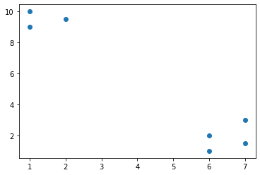

```python
plt.scatter(m_euclidean.loc['x'],m_euclidean.loc['y'])

plt.show()

plt.close()
```

```python
m_euclidean['c1'] = [(1+1+2)/3, (9+10+9.5)/3]
m_euclidean['c2'] = [(6+6+7+7)/4, (1+2+1.5+3)/4]

m_euclidean
```

|  | a | b | c | q | r | s | t | c1 | c2 |
| --- | --- | --- | --- | --- | --- | --- | --- | --- | --- |
| x | 1.0 | 1.0 | 2.0 | 6.0 | 6.0 | 7.0 | 7.0 | 1.333333 | 6.500 |
| y | 9.0 | 10.0 | 9.5 | 1.0 | 2.0 | 1.5 | 3.0 | 9.500000 | 1.875 |

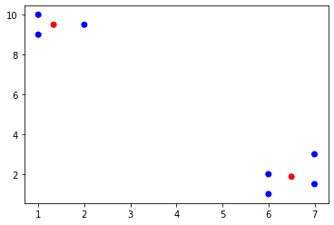

```python
plt.scatter(m_euclidean.loc['x'],m_euclidean.loc['y'], color=["blue","blue","blue","blue","blue","blue","blue","red","red"])

plt.show()

plt.close()
```

Look's good!

## One final Thing About Clustering

You might be thinking, do we always get the same clusters? No! If you are dealing with messy data, you probably will not! however, if we have distinct clusters (like below), then no matter the method (k-means or hierarchical) and no matter whether we use single, complete, or average link: we will always get the same clusters!

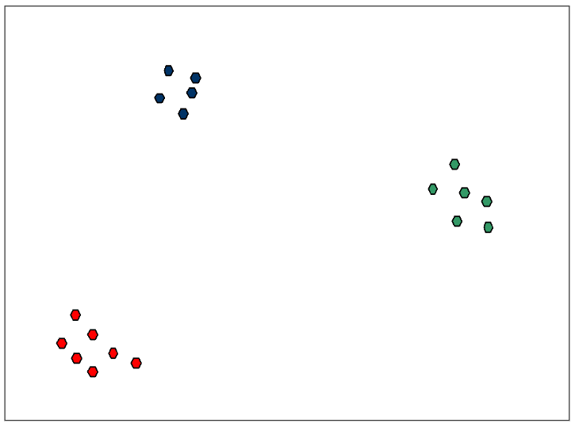

```python
Image(filename='3_clusters.png')
```

### Case 1: K=3, Pick circled points as our 3 initial points

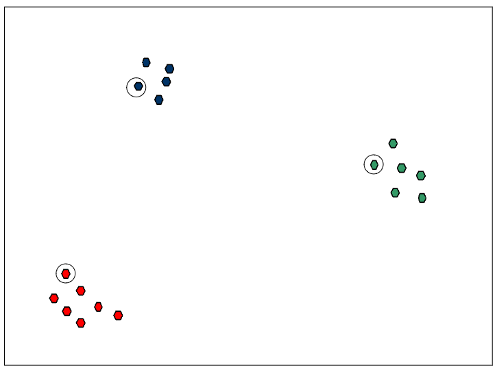

```python
Image(filename='case_1_initial_points.png')
```

Obviously we’ll get 3 Distinct Clusters

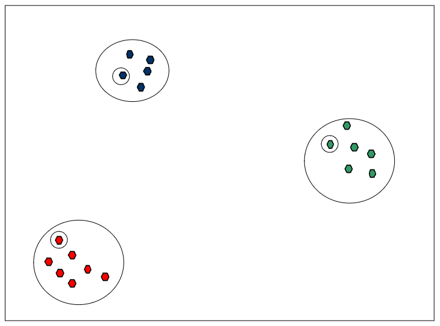

```python
Image(filename='case_1_clusters.png')
```

### Case 2: K=3, Pick circled points as our 3 initial points (This is the worst Case)

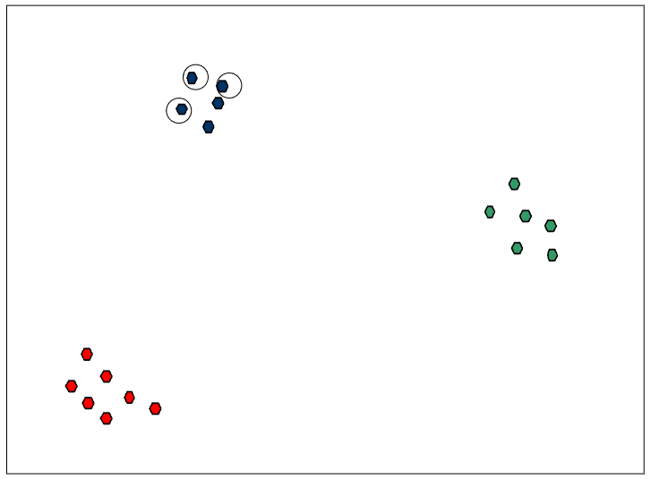

```python
Image(filename='case_2_initial_points.png')
```

### Case 2: First Iteration Iteration - Clusters

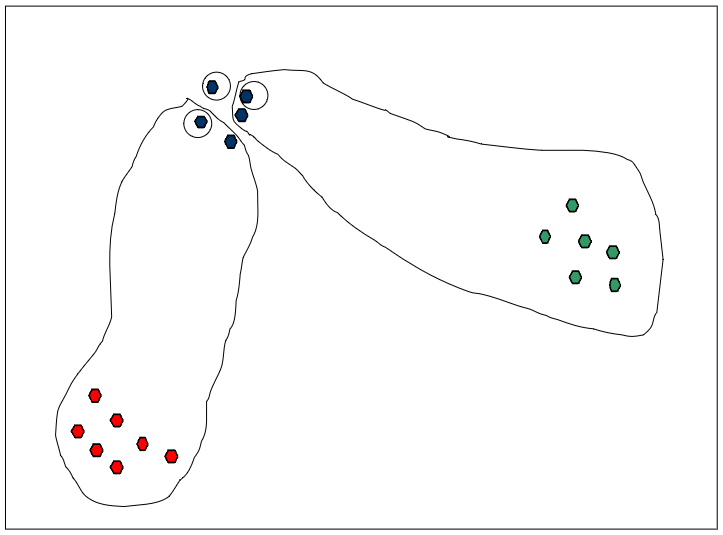

```python
Image(filename='case_2_iteration_1_clusters.png')
```

### Case 2: After 1 Iteration - Centroid Locations

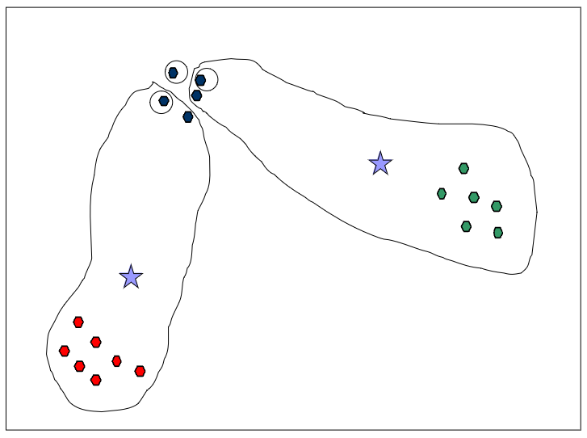

```python
Image(filename='case_2_iteration_1_centroids.png')
```

### Case 2: Second Iteration - Clusters

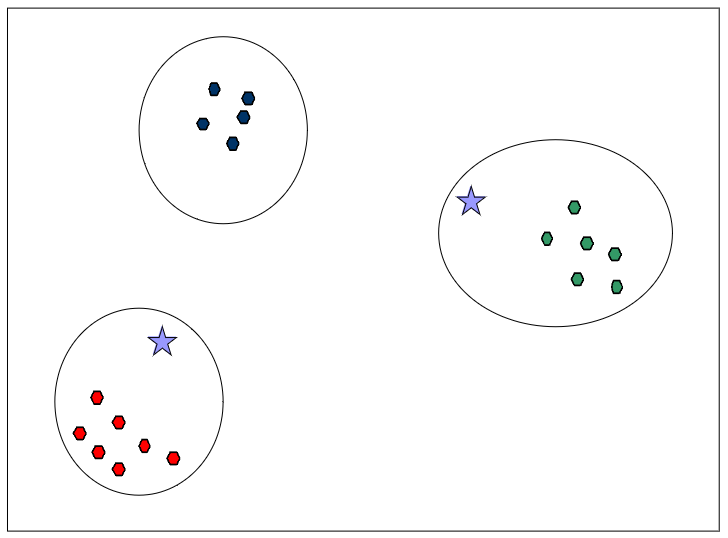

```python
Image(filename='case_2_iteration_2_clusters.png')
```

### Case 2: Second Iteration - Centroids Relocated

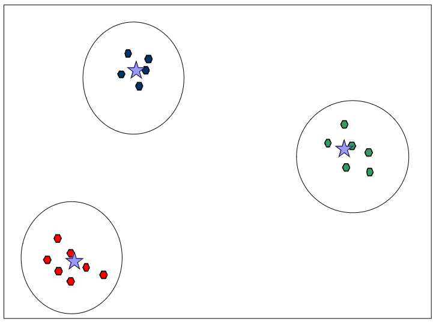

```python
Image(filename='case_2_iteration_2_centroids.png')
```

### Case 2: Third Iteration - Clusters Stabilized

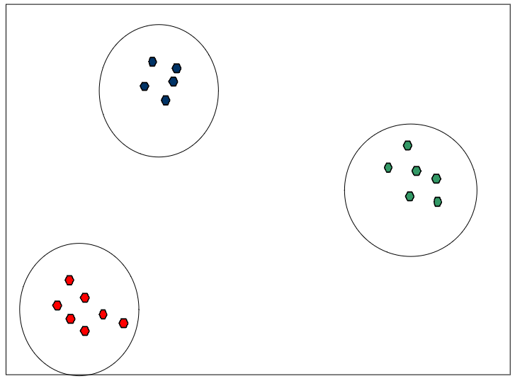

```python
Image(filename='case_2_iteration_3.png')
```

# Two Weeks and We are Finally Ready to Cluster!

We’re finally ready to do k-means clustering for our 4 documents!

|  | **Doc1** | **Doc2** | **Doc3** | **Doc4** |
| --- | --- | --- | --- | --- |
| **Doc1** | 1.00 | 0.57 | 0.00 | 0.00 |
| **Doc2** | 0.57 | 1.00 | 0.50 | 0.00 |
| **Doc3** | 0.00 | 0.50 | 1.00 | 0.39 |
| **Doc4** | 0.00 | 0.00 | 0.39 | 1.00 |

Suppose I want 2 clusters. Randomly pick 2 documents to be the first clusters (C1=Doc1, C2=Doc2). Doc3 is closer to Doc2 so it goes in c2. Doc4 is not close to either so it can go to either one. We’ll put it in C1.

Doc1,Doc4 are in c1; Doc2,Doc3 are in C2.

Recall that:

- Doc1 = <0,0,0,3,4>
- Doc2 = <0,2,0,0,2>
- Doc3 = <2,2,0,0,0>
- Doc4 = <2,0,3,0,0>

We cn simply add the vector components to get the centroids:

C1 centroid is <2,0,3,3,4>  
C2 centroid is <2,4,0,0,2>

I now recompute the distance of each document to the above centroids and see if anything moves. But that is the general idea!

# Final Thoughts on Clustering

K-means is fast but not necessarily repeatable!You need to know how many clusters you want at start.  
Hierarchical Clustering - Slower but you can pick the number of clusters by cutting.  
MST clustering. Cool, but not popular.

There's a two interesting .html files on Canvas Week 4 for some more examples on clustering in Python; feel free to check them out!

# What's Cooking Contest

This is an expired contest from Kaggle! I have a training set and a testing set, so we can run an internal contest. Should be fun and informative. I’ve done these before and everyone thinks it’s great when someone beats the professor!

## Rules of the Game

I’ve got 30,000+ training records filled with ingredients plus a tag that says whether the cuisine is Greek, Italian, Indian, etc.

I have a hidden testing set that I will send in 2 weeks that you will use to predict the cuisine

This is like real-life where we don’t always have a testing set because the testing set consists of future customers (e.g. predicting credit risk)

How to proceed? Split the training set into 80% training and 20% validation and build the model on the 80% and validate on the 20%.

## How to Proceed?

Any way you want! You could build a bag-of-words model based on something like TF-IDF and put the cuisines into clusters. You could do K-nearest neighbors! You could build a neural network, or an SVM etc!

You will be working in your groups (great practice for both your final project and future careers)! You can use R, Python, Java, whatever you want.

I will need both you code and your submission file (there's a sample format file in the assignment section)

The top I will then rank the top scores and give extra credit to groups based on performance (If 5 groups, first gets +5, second gets +4 etc.)

### However!

If you get a 100% then you get 8/10!

Why?

Because if you get 100% you almost certainly ran the model on some training set you found on the internet and you managed to overtrain your model.

This has happened before. I get someone who gets 100% and then I retrain the model on my supplied training set and it gets 75% correct.

So make sure you train your model on the training set I supply you.

There is a sample file in week 4 to see what Dr. Breizman did for your review.